# Reading in text data and create a DFM

18 April 2018

This document introduces the steps of going from raw texts to a document term matrix that can be analyzed.

## Reading in data

Let’s take a look a set of UK prime minister speeches from the [EUSpeech](https://dataverse.harvard.edu/dataverse/euspeech) dataset.

NB: Use setwd() to set the working directory to the folder that contains English speeches in the file speeches_uk.csv. Read in the speeches as follows using `readtext`:

```r
Sys.setlocale(locale = "en_US.UTF-8")
```

```
## [1] "en_US.UTF-8/en_US.UTF-8/en_US.UTF-8/C/en_US.UTF-8/C"
```

```r
library(readtext)
speeches <- readtext("speeches_uk.csv", text_field = "text")
```

Let’s do some very light cleaning on these speeches

```r
#remove p tags
speeches$text <- gsub("<.*?>", "", speeches$text)
```

Our speeches object is currently a dataframe. To be able to apply functions in `quanteda` on this object it needs to recognize it as a corpus. For this, you use the `corpus()` function. `corpus()` will recognize that `speeches$text` contains the speeches because it is defined as such in the `text_field` option when we called `readtext()`:

```r
library(quanteda)
corpus <- corpus(speeches)
ndoc(corpus)
```

```
## [1] 787
```

```r
#subsetting a corpus is easy using corpus_subset()
cameron.corpus <- corpus_subset(corpus, speaker == "D. Cameron")
ndoc(cameron.corpus)
```

```
## [1] 493
```

Metadata such as speaker, date, etc. are stored in a corpus object as docvars, and can be accessed like so (we’ll use the `head()` function to limit the output):

```r
#speaker
head(docvars(corpus, "speaker"), 10)
```

```
##  [1] "D. Cameron" "D. Cameron" "D. Cameron" "D. Cameron" "D. Cameron"
##  [6] "D. Cameron" "D. Cameron" "D. Cameron" "D. Cameron" "D. Cameron"
```

```r
#date
head(docvars(corpus, "date"), 10)
```

```
##  [1] "18-12-2015" "10-12-2015" "09-12-2015" "07-12-2015" "07-12-2015"
##  [6] "01-12-2015" "28-11-2015" "23-11-2015" "19-11-2015" "16-11-2015"
```

```r
#use the unique() function to check the number of unique speakers
unique(docvars(corpus, "speaker"))
```

```
## [1] "D. Cameron" "G. Brown"   "T. Blair"
```

Sometimes it can be useful to tokenize your corpus. You can do this using the `tokens()` function.

```r
tokens.speech <- tokens(corpus)
```

*NB:* the `tokens()` function generates a list that contains token vectors for all documents in the corpus. A list is an `R` object that can contain vectors of various lengths and types and as such is different from a dataframe which can contain variables of multiple types but with equal length.

Let’s turn the corpus into a dfm using the `dfm()` function in `quanteda`:

```r
corpus.dfm <- dfm(corpus, stem = TRUE, remove=stopwords("english"), remove_punct=TRUE)
#let's select those tokens that appear in at least 10 documents
corpus.dfm = dfm_trim(corpus.dfm, min_docfreq = 10)
corpus.dfm
```

```
## Document-feature matrix of: 787 documents, 4,205 features (89.5% sparse).
```

*NB:* Because most words don’t occur in most documents, a dtm often contains many zeroes (sparse). Internally, `quanteda` stores the dfm in a sparse format, which means that the zeroes are not stored, so you can create a dtm of many documents and many words without running into memory problems.

## Visualization in quanteda

`Quanteda` contains some very useful functions to plot your corpus in order get a feel for it. For example, it is easy to construct a wordcloud to see which features appear most often in your corpus (NB: don’t overinterpret a word cloud)

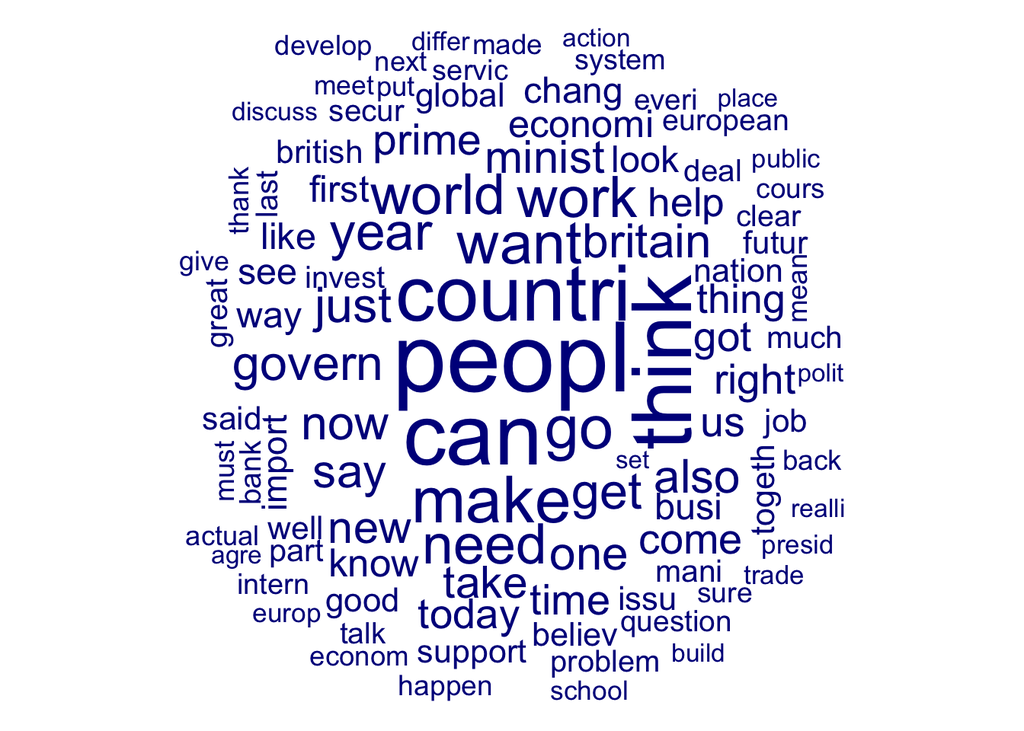

```r
textplot_wordcloud(corpus.dfm, max.words=100)
```

Let’s say we are interested in which words are spoken relatively more often by David Cameron than by Tony Blair and Gordon Brown. For this we can use `textstat_keyness()` and `textplot_keyness()` functions.

```r
cameron <- docvars(corpus, "speaker") == "D. Cameron"
comparison <- textstat_keyness(corpus.dfm, cameron)
head(comparison)
```

```
##   feature     chi2 p n_target n_reference
## 1    good 366.2716 0     2055         705
## 2      eu 347.0716 0      817         128
## 3 eurozon 332.9712 0      469          11
## 4   syria 309.0739 0      438          11
## 5   think 290.1130 0     5990        3199
## 6   thing 277.0692 0     2617        1128
```

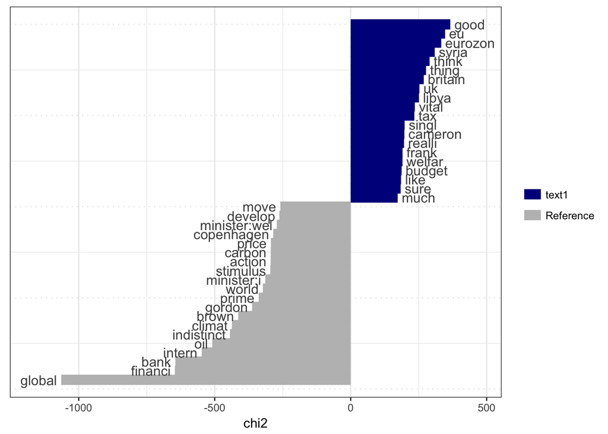

```r
textplot_keyness(comparison)
```